# Drawing production analyses: Figure 2 and related appendix

Bria Long

2022-07-14

# Libraries

```r
load(file=here::here('data/preprocessed_data/merged_vgg_class_and_meta.RData'))
```

```r
load(file=here::here('data/preprocessed_data/merged_clip_class_and_meta.RData'))
```

## Figure 2A: Classification by age

```r
## first summarize data
cor_by_age <- d %>%
  group_by(age_numeric,category) %>%
  summarize(avg_cor = mean(correct_or_not)) %>%
  group_by(age_numeric) %>%
  multi_boot_standard(col = "avg_cor")

cor_by_category <- d %>%
  group_by(age_numeric,category) %>%
  dplyr::summarize(mean = mean(correct_or_not), num_drawings = n()) %>%
  group_by(age_numeric)
```

```r
## first summarize data
clip_cor_by_age <- d_clip %>%
  group_by(age_numeric,category) %>%
  summarize(avg_cor = mean(correct_or_not)) %>%
  group_by(age_numeric) %>%
  multi_boot_standard(col = "avg_cor")

clip_cor_by_category <- d_clip %>%
  group_by(age_numeric,category) %>%
  dplyr::summarize(mean = mean(correct_or_not), num_drawings = n()) %>%
  group_by(age_numeric)
```

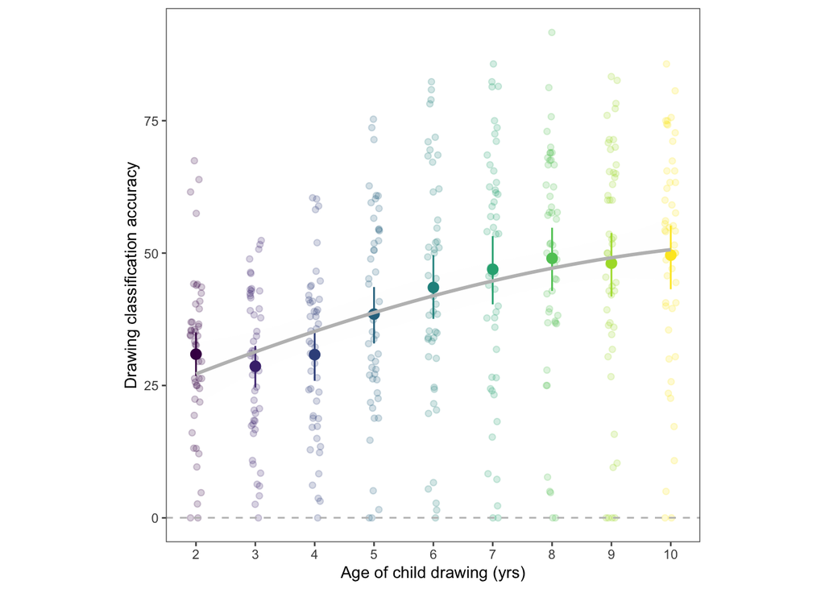

```r
base_size_chosen=10
smooth_alpha=.01
ggplot(cor_by_age, aes(age_numeric,mean*100, col=age_numeric)) +
  geom_jitter(data=cor_by_category, width=.1, height=0, alpha=.2) +
  geom_pointrange(aes(y=mean*100, ymin = ci_lower*100, ymax = ci_upper*100)) +
  geom_smooth(alpha=smooth_alpha, color='grey', span=5) +
  theme_few(base_size = base_size_chosen) +
  # geom_line(data = cor_by_category, aes(group=category), alpha=.2) +
  labs(x='Age of child drawing (yrs)', y='Drawing classification accuracy') +
  scale_x_continuous(breaks = seq(2,10,1)) +
  theme(legend.position = "none", aspect.ratio = 1) +
  scale_color_viridis(option="D", breaks=seq(3,10,1)) +
  geom_hline(yintercept = 1/48, linetype="dashed", color="grey")
```

```r
# ggsave(here::here('data/figures_out/Figure2A_cor_by_category_by_age.pdf'), width=3, height=3, units='in')

# write_csv(cor_by_age, file = here::here('data/figures_csvs/Figure2A_cor_by_category_by_age.csv'))
```

## Appendix: CLIP classifications by age

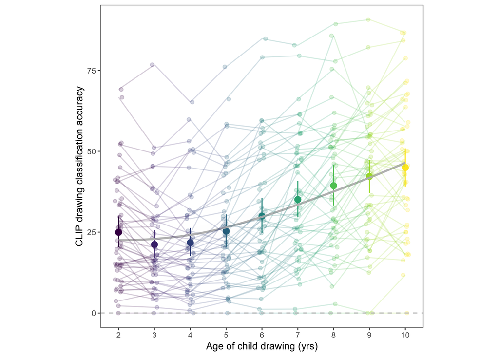

```r
base_size_chosen=10
smooth_alpha=.01
ggplot(clip_cor_by_age, aes(age_numeric,mean*100, col=age_numeric)) +
  geom_jitter(data=clip_cor_by_category, width=.1, height=0, alpha=.2) +
  geom_pointrange(aes(y=mean*100, ymin = ci_lower*100, ymax = ci_upper*100)) +
  geom_smooth(alpha=smooth_alpha, color='grey', span=2) +
  theme_few(base_size = base_size_chosen) +
  geom_line(data = clip_cor_by_category, aes(group=category), alpha=.2) +
  labs(x='Age of child drawing (yrs)', y='CLIP drawing classification accuracy') +
  scale_x_continuous(breaks = seq(2,10,1)) +
  theme(legend.position = "none", aspect.ratio = 1) +
  scale_color_viridis(option="D", breaks=seq(2,10,1)) +
  geom_hline(yintercept = 1/48, linetype="dashed", color="grey")
```

```r
ggsave(here::here('data/figures_out/Appendix_A2_clip_cor_by_age_and_category.pdf'), width=3, height=3, units='in')
write_csv(clip_cor_by_age, file = here::here('data/figures_csvs/Appendix_A2_clip_cor_by_age_and_category.csv'))
```

## Appendix: Classification by each VGG Layer

```r
load(file=here::here('data/preprocessed_data/vgg_outputs_by_layer.RData'))
```

```r
cor_by_age_by_all_layers <- all_layer_class %>%
  group_by(layer, age_numeric, category) %>%
  summarize(avg_correct = mean(as.logical(correct_or_not))) %>%
  group_by(layer, age_numeric) %>%
  multi_boot_standard(col = 'avg_correct')

cor_by_age_by_all_layers$layer_ordered = factor(cor_by_age_by_all_layers$layer, levels = c('P1','P2','P3','P4','P5','FC6','FC7'))
```

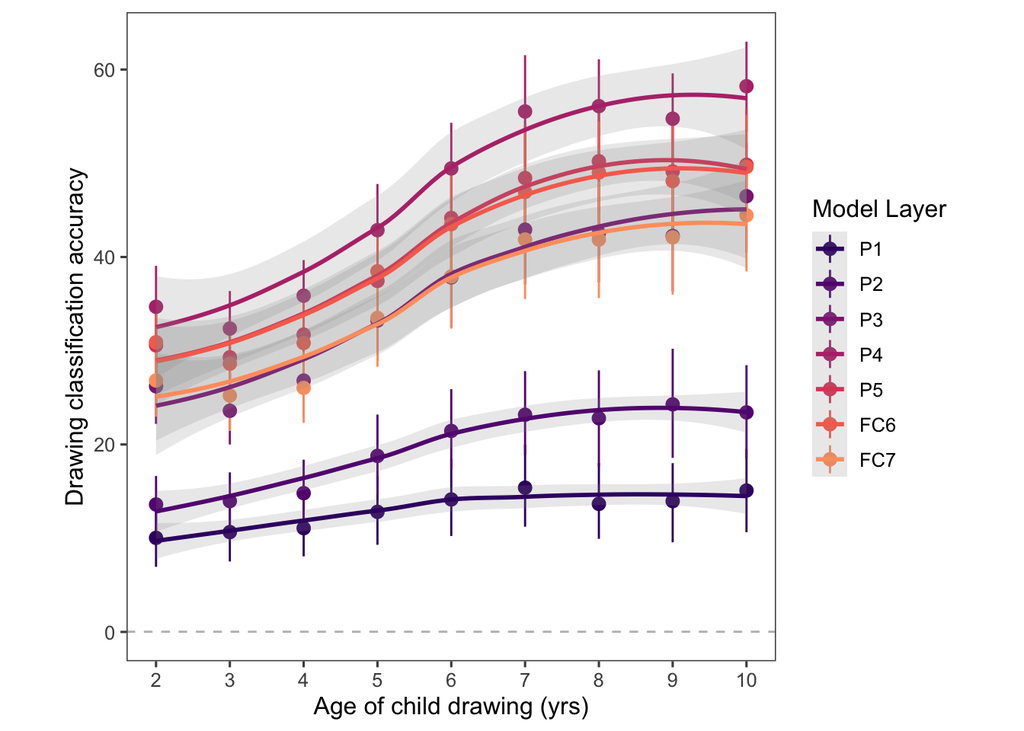

```r
ggplot(cor_by_age_by_all_layers, aes(age_numeric,mean*100, color=layer_ordered, group=layer_ordered)) +
  # geom_jitter(data=cor_by_category, width=.1, height=0, alpha=.2) +
  geom_pointrange(aes(y=mean*100, ymin = ci_lower*100, ymax = ci_upper*100)) +
  geom_smooth(alpha=.2, span=1) +
  theme_few(base_size = 12) +
  labs(x='Age of child drawing (yrs)', y='Drawing classification accuracy') +
  scale_x_continuous(breaks = seq(2,10,1)) +
  theme(legend.position = "right", aspect.ratio = 1) +
  scale_color_viridis(option="A", discrete=TRUE, begin=.2, end=.8, name = "Model Layer") +
  geom_hline(yintercept = 1/48, linetype="dashed", color="grey")
```

```r
ggsave(here::here('data/figures_out/Appendix_A5_vggcorbylayer.pdf'), width=5, height=3, units='in')
write_csv(cor_by_age_by_all_layers, file = here::here('data/figures_csvs/Appendix_A5_vggcorbylayer.csv'))
```

```r
lo_correct_category_by_age <- d %>%
  filter(correct_or_not==1) %>%
  mutate(category = str_replace(category,'ice.cream','ice cream')) %>%  # ice.cream -> ice_cream
  mutate(age = cut(age_numeric, c(1.9, 5, 8,10.1), labels = c("2-4","5-7","8-10"))) %>%
  group_by(session_id, age,category) %>%
  summarize(avg_cor = mean(log_odds), num_drawings = n()) %>%
  group_by(age, category) %>%
  multi_boot_standard(col = 'avg_cor') %>%
  ungroup () %>%
  mutate(category = fct_reorder(category, mean))
```

## VGG category effects

```r
lo_correct_category_by_each_age <- d %>%
  filter(correct_or_not==1) %>%
  mutate(category = str_replace(category,'ice.cream','ice cream')) %>%  # ice.cream -> ice_cream
  group_by(session_id, age_numeric,category) %>%
  summarize(avg_cor = mean(log_odds), num_drawings = n()) %>%
  group_by(age_numeric, category) %>%
  multi_boot_standard(col = 'avg_cor') %>%
  ungroup () %>%
  mutate(category = fct_reorder(category, -mean))

lo_all_drawings_by_each_age <- d %>%
  mutate(category = str_replace(category,'ice.cream','ice cream')) %>%  # ice.cream -> ice_cream
  group_by(session_id, age_numeric,category) %>%
  summarize(avg_cor = mean(log_odds), num_drawings = n()) %>%
  group_by(age_numeric, category) %>%
  multi_boot_standard(col = 'avg_cor') %>%
  ungroup () %>%
  mutate(category = fct_reorder(category, -mean))


lo_all_drawings_by_each_age_count<- d %>%
  mutate(category = str_replace(category,'ice.cream','ice cream')) %>%  # ice.cream -> ice_cream
  group_by(age_numeric,category) %>%
  summarize(avg_cor = mean(log_odds), num_drawings = n())

mean(lo_all_drawings_by_each_age_count$num_drawings)
```

```
## [1] 51.55556
```

## Figure 2B: Changes in log-odds by age

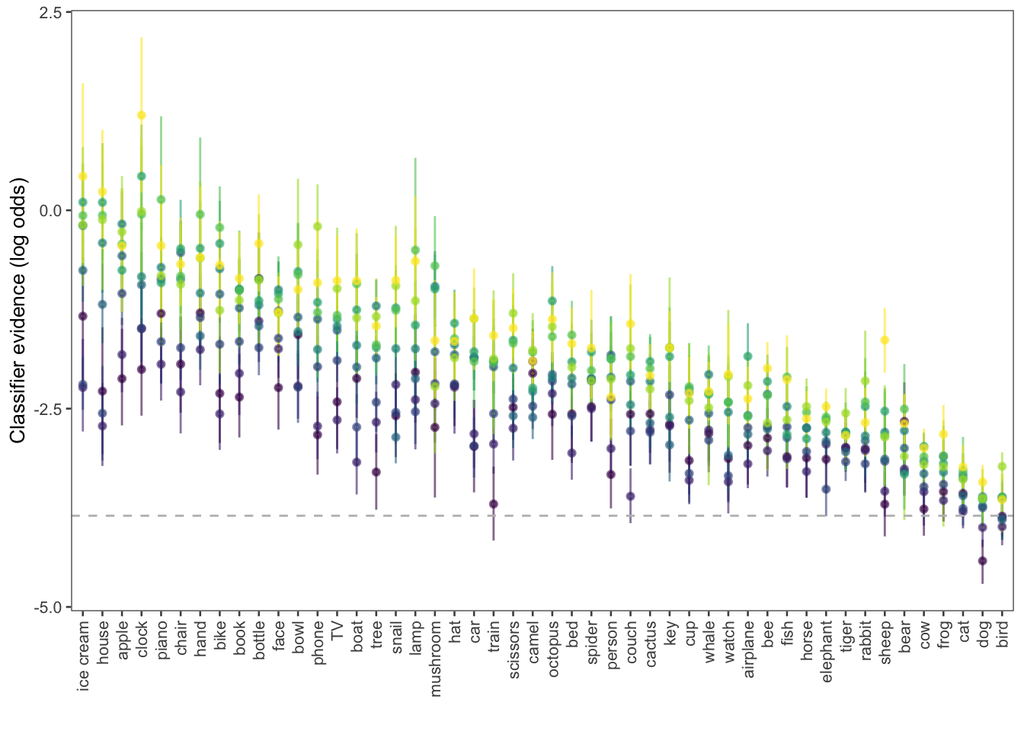

```r
num_classes=48
chance = log(1/num_classes) - log ((num_classes - 1)/num_classes)
base_size_chosen=10
ggplot(lo_all_drawings_by_each_age, aes(x = category, y = mean, col = age_numeric)) +
  geom_pointrange(aes(ymin = ci_lower, ymax = ci_upper), alpha=.6, size=.2) +
  # coord_flip() +
  theme_few(base_size = base_size_chosen) +
  labs(y = "Classifier evidence (log odds)", x = "") +
  scale_color_viridis(discrete=FALSE) +
  theme(axis.text.x = element_text(angle = 90, vjust = 0.5, hjust=1)) +
  geom_hline(yintercept=chance, color='grey', linetype = 'dashed') +
  theme(legend.position = 'none')
```

```r
ggsave(filename = here::here('data/figures_out/Figure2B_log_odds_by_category_all_drawings.pdf'), units = 'in', height= 3, width=5, useDingbats=FALSE)


write_csv(lo_all_drawings_by_each_age, file = here::here('data/figures_csvs/Figure2B_log_odds_by_category_all_drawings.csv'))
```

## LO for correctly classified drawings only; not in paper.

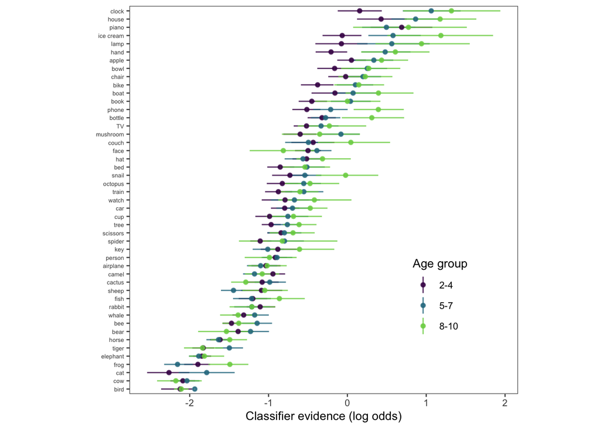

```r
num_classes=48
chance = log(1/num_classes) - log ((num_classes - 1)/num_classes)
base_size_chosen=10
ggplot(lo_correct_category_by_age, aes(x = category, y = mean, col = age)) +
  geom_pointrange(aes(ymin = ci_lower, ymax = ci_upper), alpha=.8, size=.2) +
  coord_flip() +
  theme_few(base_size = base_size_chosen) +
  labs(y = "Classifier evidence (log odds)", x = "") +
  scale_color_viridis(discrete=TRUE, begin=0, end=.8, name = "Age group") +
  theme(legend.position = c(.8,.25), axis.text.y = element_text(size=5), legend.text = element_text(size=8), legend.background =  element_rect(fill=alpha('white', 0)), aspect.ratio=1)
```

```r
# ggsave("figures_out/Appendix_correct_log_odds_by_category.pdf", units = 'in', height= 3)
```

## Appendix: CLIP log odds by category by age

```r
clip_lo_correct_category_by_each_age <- d_clip %>%
  filter(correct_or_not==1) %>%
  group_by(session_id, age_numeric,category) %>%
  summarize(avg_cor = mean(log_odds), num_drawings = n()) %>%
  group_by(age_numeric, category) %>%
  multi_boot_standard(col = 'avg_cor') %>%
  ungroup () %>%
  mutate(category = fct_reorder(category, -mean))

clip_lo_category_by_each_age <- d_clip %>%
  group_by(session_id, age_numeric,category) %>%
  summarize(avg_cor = mean(log_odds), num_drawings = n()) %>%
  group_by(age_numeric, category) %>%
  multi_boot_standard(col = 'avg_cor') %>%
  ungroup () %>%
  mutate(category = fct_reorder(category, -mean))
```

[figure not shown]

```r
base_size_chosen=14
ggplot(clip_lo_correct_category_by_each_age, aes(x = category, y = mean, col = age_numeric)) +
  geom_pointrange(aes(ymin = ci_lower, ymax = ci_upper), alpha=.6, size=.4, position=position_dodge(width=.2)) +
  # coord_flip() +
  theme_few(base_size = base_size_chosen) +
  labs(y = "Classifier evidence (log odds)", x = "") +
  scale_color_viridis() +
  theme(legend.position = c(.8,.25), axis.text.y = element_text(size=9), legend.text = element_text(size=8), legend.background =  element_rect(fill=alpha('white', 0)), aspect.ratio=.75) +
    ggtitle('CLIP log odds by category for correctly classified drawings')
```

```r
# ggsave("figures_out/Appendix_clip_log_odds_by_category.pdf", units = 'in', height= 3, width=7)

# write_csv(clip_lo_correct_category_by_each_age, file = here::here('data/figures_csvs/appendix_lo_correct_category_by_each_age.csv'))
```

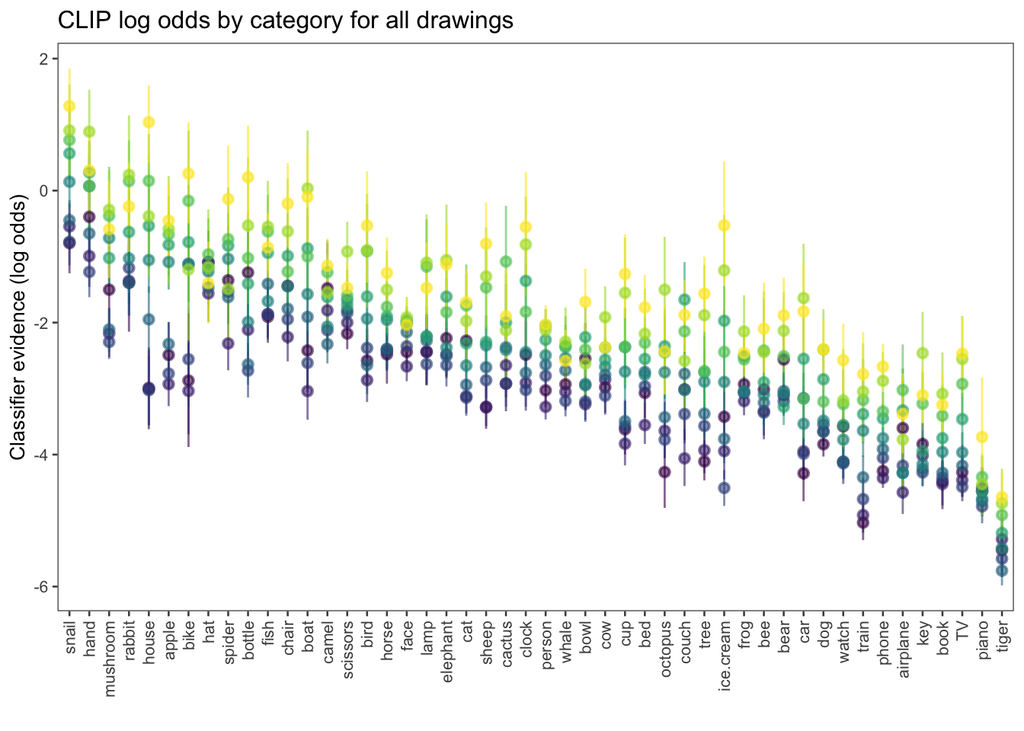

```r
base_size_chosen=10
ggplot(clip_lo_category_by_each_age, aes(x = category, y = mean, col = age_numeric)) +
  geom_pointrange(aes(ymin = ci_lower, ymax = ci_upper), alpha=.6, size=.4, position=position_dodge(width=.2)) +
  # coord_flip() +
  theme_few(base_size = base_size_chosen) +
  labs(y = "Classifier evidence (log odds)", x = "") +
  scale_color_viridis() +
  theme(axis.text.x = element_text(angle = 90, vjust = 0.5, hjust=1)) +
  theme(legend.position = 'none') +
  ggtitle('CLIP log odds by category for all drawings')
```

```r
  # theme(legend.position = c(.8,.25), axis.text.y = element_text(size=9), legend.text = element_text(size=8), legend.background =  element_rect(fill=alpha('white', 0)), aspect.ratio=.75)

ggsave(here::here('data/figures_out/Appendix_A3_clip_log_odds_by_category.pdf'), units = 'in', height= 3)

write_csv(clip_lo_category_by_each_age, file = here::here('data/figures_csvs/Appendix_A3_clip_log_odds_correct_by_category.csv'))
```

## Appendix: Controlled experiment, human classifications

```r
### Load human classification data

humans <- read.csv(here::here('data/devphotodraw_recognition_ratings/compiled_human_recognition.csv'))

devphotodraw_recog <- humans %>%
  mutate(condition = str_split_fixed(image_name_short,'_',2)[,1]) %>%
  filter(condition == 'S') %>%
  mutate(age = replace(age,age==10, 9)) %>%
  group_by(unique_ids, category, age, image_name_short) %>% # group by each drawing of each category
  summarize(prop_correct_indiv = mean(correct_or_not))  %>%
  group_by(category, age) %>%
  summarize(prop_correct =  mean(prop_correct_indiv))
```

```r
devphotodraw_recog_by_age <- humans %>%
  mutate(condition = str_split_fixed(image_name_short,'_',2)[,1]) %>%
  filter(condition == 'S') %>% # semantic cue
  filter(site == 'CDM') %>% #  CDM site (children's discovery museum)
  group_by(unique_ids, category, age, image_name_short) %>% # group by each drawing of each category
  summarize(prop_correct_indiv = mean(correct_or_not))  %>%
  group_by(age) %>%
  multi_boot_standard(col = 'prop_correct_indiv')
```

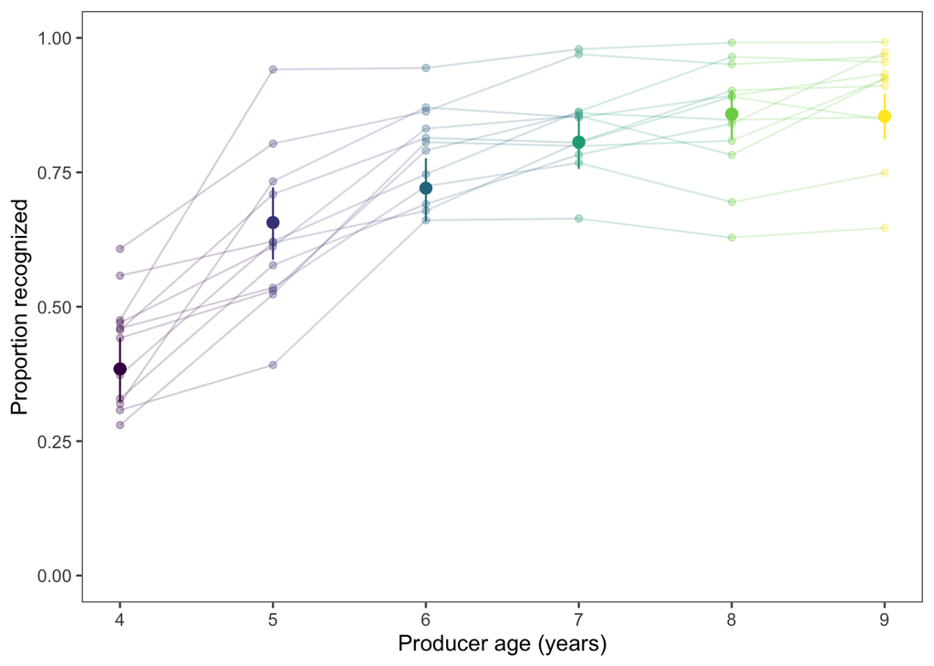

```r
ggplot(data=devphotodraw_recog, aes(x=age, y=prop_correct, color=age)) +
  geom_point(alpha=.3) +
  geom_line(aes(group=category), alpha=.2) +
  geom_pointrange(data = devphotodraw_recog_by_age, aes(ymin = ci_lower, ymax = ci_upper, y=mean, x=age))  +
  scale_color_viridis_c() +
  ylim(0,1) +
  # geom_smooth(span=5, color='grey') +
  theme_few() +
  xlab('Producer age (years)') +
  ylab('Proportion recognized') +
  theme(legend.position='none')
```

```r
ggsave(here::here('data/figures_out/Appendix_A4_experimental_context_devphotodraw_subset.pdf'), units='in', width=4, height=3)

write_csv(devphotodraw_recog, file = here::here('data/figures_csvs/Appendix_A4_experimental_context_devphotodraw_subset.csv'))
```

**R version 4.3.1 (2023-06-16)**

**Platform:** x86_64-apple-darwin20 (64-bit)

**locale:** en_US.UTF-8||en_US.UTF-8||en_US.UTF-8||C||en_US.UTF-8||en_US.UTF-8

**attached base packages:** *stats*, *graphics*, *grDevices*, *utils*, *datasets*, *methods* and *base*

**other attached packages:** *pander(v.0.6.5)*, *langcog(v.0.1.9001)*, *viridis(v.0.6.4)*, *viridisLite(v.0.4.2)*, *ggthemes(v.4.2.4)*, *assertthat(v.0.2.1)*, *here(v.1.0.1)*, *lubridate(v.1.9.2)*, *forcats(v.1.0.0)*, *stringr(v.1.5.0)*, *dplyr(v.1.1.2)*, *purrr(v.1.0.2)*, *readr(v.2.1.4)*, *tidyr(v.1.3.0)*, *tibble(v.3.2.1)*, *ggplot2(v.3.4.3)* and *tidyverse(v.2.0.0)*

**loaded via a namespace (and not attached):** *gtable(v.0.3.4)*, *xfun(v.0.40)*, *bslib(v.0.5.1)*, *htmlwidgets(v.1.6.2)*, *lattice(v.0.21-8)*, *tzdb(v.0.4.0)*, *vctrs(v.0.6.3)*, *tools(v.4.3.1)*, *generics(v.0.1.3)*, *parallel(v.4.3.1)*, *fansi(v.1.0.4)*, *highr(v.0.10)*, *cluster(v.2.1.4)*, *pkgconfig(v.2.0.3)*, *Matrix(v.1.6-1)*, *data.table(v.1.14.8)*, *checkmate(v.2.2.0)*, *lifecycle(v.1.0.3)*, *compiler(v.4.3.1)*, *farver(v.2.1.1)*, *textshaping(v.0.3.6)*, *munsell(v.0.5.0)*, *htmltools(v.0.5.6)*, *sass(v.0.4.7)*, *yaml(v.2.3.7)*, *lazyeval(v.0.2.2)*, *htmlTable(v.2.4.1)*, *Formula(v.1.2-5)*, *crayon(v.1.5.2)*, *pillar(v.1.9.0)*, *jquerylib(v.0.1.4)*, *cachem(v.1.0.8)*, *Hmisc(v.5.1-1)*, *rpart(v.4.1.19)*, *nlme(v.3.1-162)*, *tidyselect(v.1.2.0)*, *digest(v.0.6.33)*, *stringi(v.1.7.12)*, *labeling(v.0.4.2)*, *splines(v.4.3.1)*, *rprojroot(v.2.0.3)*, *fastmap(v.1.1.1)*, *grid(v.4.3.1)*, *colorspace(v.2.1-0)*, *cli(v.3.6.1)*, *magrittr(v.2.0.3)*, *base64enc(v.0.1-3)*, *utf8(v.1.2.3)*, *foreign(v.0.8-84)*, *withr(v.2.5.0)*, *scales(v.1.2.1)*, *backports(v.1.4.1)*, *bit64(v.4.0.5)*, *timechange(v.0.2.0)*, *rmarkdown(v.2.24)*, *bit(v.4.0.5)*, *nnet(v.7.3-19)*, *gridExtra(v.2.3)*, *ragg(v.1.2.5)*, *hms(v.1.1.3)*, *evaluate(v.0.21)*, *knitr(v.1.43)*, *mgcv(v.1.8-42)*, *rlang(v.1.1.1)*, *Rcpp(v.1.0.11)*, *glue(v.1.6.2)*, *vroom(v.1.6.3)*, *rstudioapi(v.0.15.0)*, *jsonlite(v.1.8.7)*, *R6(v.2.5.1)* and *systemfonts(v.1.0.4)*